# Business Statistics End of Term Assessment IB94X0 2023-2024 #1

5582162

```r
library(tidyverse)
library(emmeans)
library(lubridate)
library(car)
library(Hmisc)
library(gridExtra)
options(width=100)
```

This is to certify that the work I am submitting is my own. All external references and sources are clearly acknowledged and identified within the contents. I am aware of the University of Warwick regulation concerning plagiarism and collusion.

No substantial part(s) of the work submitted here has also been submitted by me in other assessments for accredited courses of study, and I acknowledge that if this has been done an appropriate reduction in the mark I might otherwise have received will be made

# Question 1

## Read Data

```r
bike = read_csv("London_COVID_bikes.csv")
restriction = read_csv("restrictions_daily.csv")
# Check the data type and missing values
str(bike)
```

```
## spc_tbl_ [4,812 × 15] (S3: spec_tbl_df/tbl_df/tbl/data.frame)
##  $ date                           : Date[1:4812], format: "2010-07-30" "2010-07-31" "2010-08-01" ...
##  $ Hires                          : num [1:4812] 6897 5564 4303 6642 7966 ...
##  $ schools_closed                 : num [1:4812] 0 0 0 0 0 0 0 0 0 0 ...
##  $ pubs_closed                    : num [1:4812] 0 0 0 0 0 0 0 0 0 0 ...
##  $ shops_closed                   : num [1:4812] 0 0 0 0 0 0 0 0 0 0 ...
##  $ eating_places_closed           : num [1:4812] 0 0 0 0 0 0 0 0 0 0 ...
##  $ stay_at_home                   : num [1:4812] 0 0 0 0 0 0 0 0 0 0 ...
##  $ household_mixing_indoors_banned: num [1:4812] 0 0 0 0 0 0 0 0 0 0 ...
##  $ wfh                            : num [1:4812] 0 0 0 0 0 0 0 0 0 0 ...
##  $ rule_of_6_indoors              : num [1:4812] 0 0 0 0 0 0 0 0 0 0 ...
##  $ curfew                         : num [1:4812] 0 0 0 0 0 0 0 0 0 0 ...
##  $ eat_out_to_help_out            : num [1:4812] 0 0 0 0 0 0 0 0 0 0 ...
##  $ day                            : chr [1:4812] "Fri" "Sat" "Sun" "Mon" ...
##  $ month                          : chr [1:4812] "Jul" "Jul" "Aug" "Aug" ...
##  $ year                           : num [1:4812] 2010 2010 2010 2010 2010 2010 2010 2010 2010 2010 ...
##  - attr(*, "spec")=
##   .. cols(
##   ..   date = col_date(format = ""),
##   ..   Hires = col_double(),
##   ..   schools_closed = col_double(),
##   ..   pubs_closed = col_double(),
##   ..   shops_closed = col_double(),
##   ..   eating_places_closed = col_double(),
##   ..   stay_at_home = col_double(),
##   ..   household_mixing_indoors_banned = col_double(),
##   ..   wfh = col_double(),
##   ..   rule_of_6_indoors = col_double(),
##   ..   curfew = col_double(),
##   ..   eat_out_to_help_out = col_double(),
##   ..   day = col_character(),
##   ..   month = col_character(),
##   ..   year = col_double()
##   .. )
##  - attr(*, "problems")=<externalptr>
```

```r
summary(bike)
```

```
##       date                Hires       schools_closed     pubs_closed       shops_closed
##  Min.   :2010-07-30   Min.   :    0   Min.   :0.00000   Min.   :0.00000   Min.   :0.00000
##  1st Qu.:2013-11-13   1st Qu.:19776   1st Qu.:0.00000   1st Qu.:0.00000   1st Qu.:0.00000
##  Median :2017-02-28   Median :26356   Median :0.00000   Median :0.00000   Median :0.00000
##  Mean   :2017-02-28   Mean   :26607   Mean   :0.02743   Mean   :0.05175   Mean   :0.04634
##  3rd Qu.:2020-06-15   3rd Qu.:33481   3rd Qu.:0.00000   3rd Qu.:0.00000   3rd Qu.:0.00000
##  Max.   :2023-09-30   Max.   :73094   Max.   :1.00000   Max.   :1.00000   Max.   :1.00000
##  eating_places_closed  stay_at_home     household_mixing_indoors_banned      wfh
##  Min.   :0.00000      Min.   :0.00000   Min.   :0.00000                 Min.   :0.0000
##  1st Qu.:0.00000      1st Qu.:0.00000   1st Qu.:0.00000                 1st Qu.:0.0000
##  Median :0.00000      Median :0.00000   Median :0.00000                 Median :0.0000
##  Mean   :0.05175      Mean   :0.03616   Mean   :0.06525                 Mean   :0.2273
##  3rd Qu.:0.00000      3rd Qu.:0.00000   3rd Qu.:0.00000                 3rd Qu.:0.0000
##  Max.   :1.00000      Max.   :1.00000   Max.   :1.00000                 Max.   :1.0000
##  rule_of_6_indoors     curfew        eat_out_to_help_out     day               month
##  Min.   :0.00000   Min.   :0.00000   Min.   :0.000000    Length:4812        Length:4812
##  1st Qu.:0.00000   1st Qu.:0.00000   1st Qu.:0.000000    Class :character   Class :character
##  Median :0.00000   Median :0.00000   Median :0.000000    Mode  :character   Mode  :character
##  Mean   :0.01995   Mean   :0.01164   Mean   :0.005819
##  3rd Qu.:0.00000   3rd Qu.:0.00000   3rd Qu.:0.000000
##  Max.   :1.00000   Max.   :1.00000   Max.   :1.000000
##       year
##  Min.   :2010
##  1st Qu.:2013
##  Median :2017
##  Mean   :2017
##  3rd Qu.:2020
##  Max.   :2023
```

```r
# The restriction is from 2020.03.01
str(restriction)
```

```
## spc_tbl_ [1,388 × 11] (S3: spec_tbl_df/tbl_df/tbl/data.frame)
##  $ date                           : chr [1:1388] "2020/3/1" "2020/3/2" "2020/3/3" "2020/3/4" ...
##  $ schools_closed                 : num [1:1388] 0 0 0 0 0 0 0 0 0 0 ...
##  $ pubs_closed                    : num [1:1388] 0 0 0 0 0 0 0 0 0 0 ...
##  $ shops_closed                   : num [1:1388] 0 0 0 0 0 0 0 0 0 0 ...
##  $ eating_places_closed           : num [1:1388] 0 0 0 0 0 0 0 0 0 0 ...
##  $ stay_at_home                   : num [1:1388] 0 0 0 0 0 0 0 0 0 0 ...
##  $ household_mixing_indoors_banned: num [1:1388] 0 0 0 0 0 0 0 0 0 0 ...
##  $ wfh                            : num [1:1388] 0 0 0 0 0 0 0 0 0 0 ...
##  $ rule_of_6_indoors              : num [1:1388] 0 0 0 0 0 0 0 0 0 0 ...
##  $ curfew                         : num [1:1388] 0 0 0 0 0 0 0 0 0 0 ...
##  $ eat_out_to_help_out            : num [1:1388] 0 0 0 0 0 0 0 0 0 0 ...
##  - attr(*, "spec")=
##   .. cols(
##   ..   date = col_character(),
##   ..   schools_closed = col_double(),
##   ..   pubs_closed = col_double(),
##   ..   shops_closed = col_double(),
##   ..   eating_places_closed = col_double(),
##   ..   stay_at_home = col_double(),
##   ..   household_mixing_indoors_banned = col_double(),
##   ..   wfh = col_double(),
##   ..   rule_of_6_indoors = col_double(),
##   ..   curfew = col_double(),
##   ..   eat_out_to_help_out = col_double()
##   .. )
##  - attr(*, "problems")=<externalptr>
```

```r
summary(restriction)
```

```
##      date           schools_closed    pubs_closed      shops_closed    eating_places_closed
##  Length:1388        Min.   :0.0000   Min.   :0.0000   Min.   :0.0000   Min.   :0.0000
##  Class :character   1st Qu.:0.0000   1st Qu.:0.0000   1st Qu.:0.0000   1st Qu.:0.0000
##  Mode  :character   Median :0.0000   Median :0.0000   Median :0.0000   Median :0.0000
##                     Mean   :0.0951   Mean   :0.1794   Mean   :0.1607   Mean   :0.1794
##                     3rd Qu.:0.0000   3rd Qu.:0.0000   3rd Qu.:0.0000   3rd Qu.:0.0000
##                     Max.   :1.0000   Max.   :1.0000   Max.   :1.0000   Max.   :1.0000
##   stay_at_home    household_mixing_indoors_banned      wfh         rule_of_6_indoors
##  Min.   :0.0000   Min.   :0.0000                  Min.   :0.0000   Min.   :0.00000
##  1st Qu.:0.0000   1st Qu.:0.0000                  1st Qu.:1.0000   1st Qu.:0.00000
##  Median :0.0000   Median :0.0000                  Median :1.0000   Median :0.00000
##  Mean   :0.1254   Mean   :0.2262                  Mean   :0.8444   Mean   :0.06916
##  3rd Qu.:0.0000   3rd Qu.:0.0000                  3rd Qu.:1.0000   3rd Qu.:0.00000
##  Max.   :1.0000   Max.   :1.0000                  Max.   :1.0000   Max.   :1.00000
##      curfew        eat_out_to_help_out
##  Min.   :0.00000   Min.   :0.00000
##  1st Qu.:0.00000   1st Qu.:0.00000
##  Median :0.00000   Median :0.00000
##  Mean   :0.04035   Mean   :0.02017
##  3rd Qu.:0.00000   3rd Qu.:0.00000
##  Max.   :1.00000   Max.   :1.00000
```

## Date revision

```r
# Transform the attribute of date
restriction$date = as.Date(restriction$date)

# Since we are more concerned with the influence of government measures after the COVID, so we match the dates between the original and COVID restriction dataset
bike_new = bike %>% filter(date >= min(restriction$date))
```

## Data processing

```r
# Transform binary variables and year into factor
bike_new = bike_new %>%
  mutate_at(vars(schools_closed, pubs_closed, shops_closed, eating_places_closed, stay_at_home, household_mixing_indoors_banned, wfh, rule_of_6_indoors, curfew, eat_out_to_help_out, year), as.factor)

# Transform month and day into factor and arrange them
bike_new = bike_new %>% mutate(month=factor(month, levels=c("Jan", "Feb", "Mar", "Apr", "May", "Jun", "Jul", "Aug", "Sep", "Oct", "Nov", "Dec")))

bike_new = bike_new %>% mutate(day=factor(day, levels=c("Mon", "Tue", "Wed", "Thu", "Fri", "Sat", "Sun")))
```

## Data Cleaning

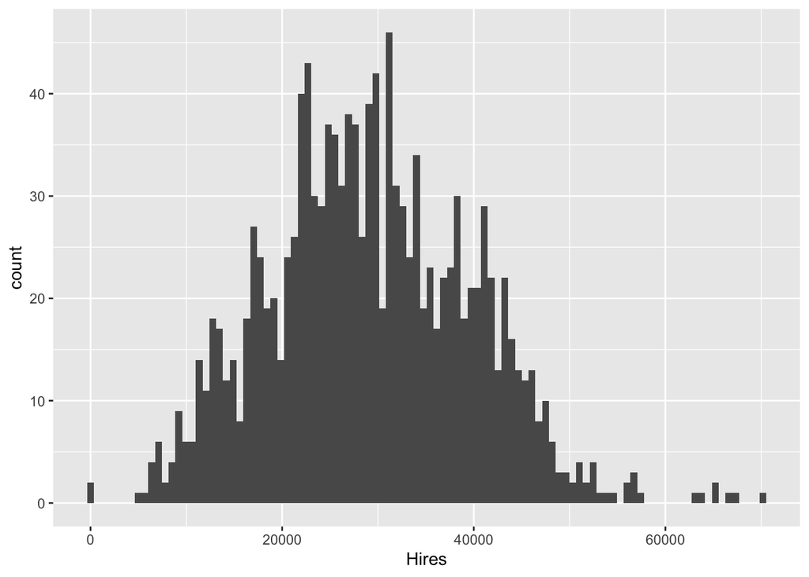

```r
# Check outliers
# It seems that there are few outliers
ggplot(bike_new) + geom_histogram(aes(Hires), bins = 100)
```

```r
# Use the Interquartile Rule to find outliers
median_value = quantile(bike_new$Hires, probs = 0.50)
q1 = quantile(bike_new$Hires, probs = 0.25)
q3 = quantile(bike_new$Hires, probs = 0.75)
iqr = q3 - q1
(lower_threshold = q1 - 1.5 * iqr)
```

```
##  25%
## 2.25
```

```r
# From upper_threshold, outliers would be the number greater than 58714
(upper_threshold = q3 + 1.5 * iqr)
```

```
##      75%
## 58714.25
```

```r
outliers = bike_new[bike_new$Hires < lower_threshold | bike_new$Hires > upper_threshold, ]
summary(outliers)
```

```
##       date                Hires       schools_closed pubs_closed shops_closed eating_places_closed
##  Min.   :2020-05-25   Min.   :    0   0:6            0:4         0:5          0:4
##  1st Qu.:2020-05-31   1st Qu.:63116   1:3            1:5         1:4          1:5
##  Median :2020-06-20   Median :65045
##  Mean   :2021-05-27   Mean   :51300
##  3rd Qu.:2022-08-19   3rd Qu.:66972
##  Max.   :2022-09-11   Max.   :70170
##
##  stay_at_home household_mixing_indoors_banned wfh   rule_of_6_indoors curfew eat_out_to_help_out
##  0:9          0:4                             0:0   0:9               0:9    0:9
##  1:0          1:5                             1:9   1:0               1:0    1:0
##
##
##
##
##
##   day        month     year
##  Mon:1   May    :3   2020:5
##  Tue:1   Jun    :3   2021:0
##  Wed:0   Sep    :2   2022:4
##  Thu:0   Aug    :1   2023:0
##  Fri:1   Jan    :0
##  Sat:4   Feb    :0
##  Sun:2   (Other):0
```

We observe that these outliers share the same features that the “work from home” variable is included. Since the effect of this variable is one of our main focuses, we choose not to remove them, except for the two outliers where the number of bike rentals is equal to 0.

```r
# Remove the outliers which the value is equal to 0
bike_new = bike_new %>% filter(Hires > 0)
```

## Regressions on the number of bike rentals

### The effect among Work From Home, Rule of 6 Indoors and Eat Out to Help Out scheme without interaction

```r
m.hires.by.mixed = lm(Hires~wfh + rule_of_6_indoors + eat_out_to_help_out, data=bike_new)
summary(m.hires.by.mixed)
```

```
##
## Call:
## lm(formula = Hires ~ wfh + rule_of_6_indoors + eat_out_to_help_out,
##     data = bike_new)
##
## Residuals:
##    Min     1Q Median     3Q    Max
## -26367  -6345   -452   5867  42769
##
## Coefficients:
##                      Estimate Std. Error t value Pr(>|t|)
## (Intercept)           34427.4      726.8  47.367  < 2e-16 ***
## wfh1                  -7026.1      786.4  -8.934  < 2e-16 ***
## rule_of_6_indoors1     7744.4     1056.9   7.327  4.1e-13 ***
## eat_out_to_help_out1   1991.0     2015.4   0.988    0.323
## ---
## Signif. codes:  0 '***' 0.001 '**' 0.01 '*' 0.05 '.' 0.1 ' ' 1
##
## Residual standard error: 9947 on 1304 degrees of freedom
## Multiple R-squared:  0.09841,    Adjusted R-squared:  0.09634
## F-statistic: 47.45 on 3 and 1304 DF,  p-value: < 2.2e-16
```

```r
cbind(coef(m.hires.by.mixed), confint(m.hires.by.mixed))
```

```
##                                    2.5 %    97.5 %
## (Intercept)          34427.419 33001.552 35853.285
## wfh1                 -7026.068 -8568.861 -5483.275
## rule_of_6_indoors1    7744.415  5670.999  9817.831
## eat_out_to_help_out1  1991.010 -1962.674  5944.694
```

The result shows that there is a significant negative effect of work from home on the number of bike rentals (b = -7026.1, CI[-8568.86, -5483.28], t(1304) = -8.93, p < 0.001), and a a significant positive effect of rule of 6 indoors (b = 7744.4, CI [5671.00, 9817.83], t(1304) = 7.33, p < 0.001). However, there is no significant effect of the eat out to help out scheme (b = 1991.0, CI = [-1962.67, 5944.69], t(1304) = 0.99, p = 0.32).

```r
# The vif scores are all low, so there is no multicollinearity problem
vif(m.hires.by.mixed)
```

```
##                 wfh   rule_of_6_indoors eat_out_to_help_out
##            1.127286            1.004360            1.124901
```

### The effect among the above three elements with interaction

```r
m.hires.by.mixed.intr = lm(Hires~wfh * rule_of_6_indoors * eat_out_to_help_out, data=bike_new)
summary(m.hires.by.mixed.intr)
```

```
##
## Call:
## lm(formula = Hires ~ wfh * rule_of_6_indoors * eat_out_to_help_out,
##     data = bike_new)
##
## Residuals:
##    Min     1Q Median     3Q    Max
## -26325  -6348   -514   5889  42765
##
## Coefficients: (3 not defined because of singularities)
##                                              Estimate Std. Error t value Pr(>|t|)
## (Intercept)                                   34406.8      741.7  46.392   <2e-16 ***
## wfh1                                          -7001.7      805.4  -8.694   <2e-16 ***
## rule_of_6_indoors1                             8229.7     3595.3   2.289   0.0222 *
## eat_out_to_help_out1                           2011.7     2021.4   0.995   0.3198
## wfh1:rule_of_6_indoors1                        -531.3     3761.6  -0.141   0.8877
## wfh1:eat_out_to_help_out1                          NA         NA      NA       NA
## rule_of_6_indoors1:eat_out_to_help_out1            NA         NA      NA       NA
## wfh1:rule_of_6_indoors1:eat_out_to_help_out1       NA         NA      NA       NA
## ---
## Signif. codes:  0 '***' 0.001 '**' 0.01 '*' 0.05 '.' 0.1 ' ' 1
##
## Residual standard error: 9950 on 1303 degrees of freedom
## Multiple R-squared:  0.09842,    Adjusted R-squared:  0.09566
## F-statistic: 35.56 on 4 and 1303 DF,  p-value: < 2.2e-16
```

```r
cbind(coef(m.hires.by.mixed.intr), confint(m.hires.by.mixed.intr))
```

```
##                                                             2.5 %    97.5 %
## (Intercept)                                  34406.7667 32951.803 35861.730
## wfh1                                         -7001.7139 -8581.729 -5421.699
## rule_of_6_indoors1                            8229.7333  1176.536 15282.931
## eat_out_to_help_out1                          2011.6619 -1953.900  5977.224
## wfh1:rule_of_6_indoors1                       -531.2634 -7910.775  6848.248
## wfh1:eat_out_to_help_out1                            NA        NA        NA
## rule_of_6_indoors1:eat_out_to_help_out1              NA        NA        NA
## wfh1:rule_of_6_indoors1:eat_out_to_help_out1         NA        NA        NA
```

The result shows that there is a significant negative effect of work from home on the number of bike rentals (b = -7001.7, CI[-8581.73, -5421.70], t(1303) = -8.69, p < 0.001) and a significant positive effect of rule of 6 indoors (b = 8229.7, CI[1176.54, 15282.93], t(1303) = 2.29, p = 0.02). However there is no significant effect of eat out to help out scheme (b = 2011.7, CI[-1953.90, 5977.22], t(1303) = 1.00, p = 0.32) and the interaction term between work from home and rule of 6 indoors (b = -531.3, CI[-7910.78, 6848.25], t(1303) = -0.14, p = 0.89). In addition, there are missing values for other interaction terms, meaning that there may be a multicollinearity problem.

```r
# The result when running vif(m.hires.by.mixed.intr) shows that the vif scores cannot be calculated due to aliased coefficients, meaning that there is a multicollinearity problem

# Also check if these elements have high correlations
# No high pairwise correlations between these elements
rcorr(as.matrix(select(bike_new, Hires, wfh, rule_of_6_indoors, eat_out_to_help_out)))
```

```
##                     Hires   wfh rule_of_6_indoors eat_out_to_help_out
## Hires                1.00 -0.25              0.18                0.10
## wfh                 -0.25  1.00              0.06               -0.33
## rule_of_6_indoors    0.18  0.06              1.00               -0.04
## eat_out_to_help_out  0.10 -0.33             -0.04                1.00
##
## n= 1308
##
##
## P
##                     Hires  wfh    rule_of_6_indoors eat_out_to_help_out
## Hires                      0.0000 0.0000            0.0002
## wfh                 0.0000        0.0249            0.0000
## rule_of_6_indoors   0.0000 0.0249                   0.1324
## eat_out_to_help_out 0.0002 0.0000 0.1324
```

```r
anova(m.hires.by.mixed, m.hires.by.mixed.intr)
```

```
## Analysis of Variance Table
##
## Model 1: Hires ~ wfh + rule_of_6_indoors + eat_out_to_help_out
## Model 2: Hires ~ wfh * rule_of_6_indoors * eat_out_to_help_out
##   Res.Df        RSS Df Sum of Sq      F Pr(>F)
## 1   1304 1.2901e+11
## 2   1303 1.2901e+11  1   1974883 0.0199 0.8877
```

The anova result shows that the model with interaction has no significant improvement (F(1304, 1303) = 0.020, p = 0.89), so we wouldn’t adopt this model (with interaction).

### The effect among Work From Home, Rule of 6 Indoors, Eat Out to Help Out scheme and date(year, month, day) without interaction

Given the need to interpret model results, we are particularly interested in the comprehensive impact of COVID-related measures and time on bicycle rentals (not only consider the impact of time on bicycle rentals).

```r
m.hires.by.mixed.date = lm(Hires~wfh + rule_of_6_indoors + eat_out_to_help_out + day + month + year, data=bike_new)
summary(m.hires.by.mixed.date)
```

```
##
## Call:
## lm(formula = Hires ~ wfh + rule_of_6_indoors + eat_out_to_help_out +
##     day + month + year, data = bike_new)
##
## Residuals:
##    Min     1Q Median     3Q    Max
## -22303  -4543    445   4580  36818
##
## Coefficients:
##                      Estimate Std. Error t value Pr(>|t|)
## (Intercept)           23939.9     1320.0  18.136  < 2e-16 ***
## wfh1                  -7646.5      800.8  -9.548  < 2e-16 ***
## rule_of_6_indoors1     2558.5      913.3   2.801 0.005166 **
## eat_out_to_help_out1  -2594.2     1752.2  -1.481 0.138969
## dayTue                 2745.2      767.1   3.579 0.000358 ***
## dayWed                 2714.8      767.2   3.539 0.000417 ***
## dayThu                 2918.0      767.4   3.803 0.000150 ***
## dayFri                 2019.3      767.4   2.631 0.008604 **
## daySat                 4305.1      768.3   5.604 2.57e-08 ***
## daySun                  563.1      768.1   0.733 0.463624
## monthFeb               3666.6     1117.9   3.280 0.001066 **
## monthMar               4530.1     1032.6   4.387 1.24e-05 ***
## monthApr               8136.2     1034.6   7.864 7.81e-15 ***
## monthMay              13922.5     1032.0  13.491  < 2e-16 ***
## monthJun              18305.4     1057.3  17.313  < 2e-16 ***
## monthJul              16193.5     1040.8  15.559  < 2e-16 ***
## monthAug              12892.0     1117.4  11.538  < 2e-16 ***
## monthSep              11717.2     1111.9  10.538  < 2e-16 ***
## monthOct               7287.7     1150.7   6.333 3.31e-10 ***
## monthNov               4443.3     1144.4   3.883 0.000109 ***
## monthDec              -2489.3     1111.8  -2.239 0.025320 *
## year2021               -236.1      650.6  -0.363 0.716737
## year2022               5009.4      625.5   8.008 2.58e-15 ***
## year2023              -4257.5      685.8  -6.208 7.22e-10 ***
## ---
## Signif. codes:  0 '***' 0.001 '**' 0.01 '*' 0.05 '.' 0.1 ' ' 1
##
## Residual standard error: 7426 on 1284 degrees of freedom
## Multiple R-squared:  0.5052, Adjusted R-squared:  0.4963
## F-statistic:    57 on 23 and 1284 DF,  p-value: < 2.2e-16
```

```r
cbind(coef(m.hires.by.mixed.date), confint(m.hires.by.mixed.date))
```

```
##                                      2.5 %     97.5 %
## (Intercept)          23939.8774 21350.2977 26529.4572
## wfh1                 -7646.5329 -9217.6212 -6075.4446
## rule_of_6_indoors1    2558.5060   766.7347  4350.2773
## eat_out_to_help_out1 -2594.1675 -6031.5636   843.2286
## dayTue                2745.1548  1240.2539  4250.0557
## dayWed                2714.8407  1209.7046  4219.9768
## dayThu                2917.9733  1412.5576  4423.3891
## dayFri                2019.2644   513.8401  3524.6887
## daySat                4305.0535  2797.8700  5812.2371
## daySun                 563.0874  -943.7382  2069.9130
## monthFeb              3666.6496  1473.5929  5859.7064
## monthMar              4530.0629  2504.2773  6555.8485
## monthApr              8136.1948  6106.5835 10165.8060
## monthMay             13922.5422 11897.9711 15947.1134
## monthJun             18305.4125 16231.1688 20379.6562
## monthJul             16193.4973 14151.6374 18235.3571
## monthAug             12891.9509 10699.9017 15084.0002
## monthSep             11717.1818  9535.8729 13898.4907
## monthOct              7287.7122  5030.2813  9545.1432
## monthNov              4443.3094  2198.2289  6688.3899
## monthDec             -2489.3386 -4670.4053  -308.2719
## year2021              -236.0945 -1512.3936  1040.2045
## year2022              5009.4423  3782.2912  6236.5934
## year2023             -4257.4548 -5602.8043 -2912.1053
```

The result shows that almost every elements has a significant positive effect on the number of bike rentals, while there is a negative effect of work from home, December and year 2023. Furthermore, there is no significant effect of the eat out to help out scheme, Sunday and year 2021.

```r
# The vif scores are all low, so there is no multicollinearity problem
vif(m.hires.by.mixed.date)
```

```
##                         GVIF Df GVIF^(1/(2*Df))
## wfh                 2.097343  1        1.448221
## rule_of_6_indoors   1.345646  1        1.160020
## eat_out_to_help_out 1.525524  1        1.235121
## day                 1.004515  6        1.000376
## month               2.245391 11        1.037452
## year                2.033447  3        1.125569
```

If we consider the interaction effect, the result would be very complex, so we wouldn’t consider to include that in this case.

# Conclusion

This section presents the results of the analyses that examine the effect on the number of bike rentals. There are 4812 records in the original dataset from 30th July 2010 to 30th September 2023, but we choose to focus on the impact of policies on the number of bike rentals after the COVID. After data processing, 1310 records are left for analysis between 1st March 2020 and 30th September 2023. The dataset contains a small amount of outliers, which might affect the accuracy of the data. However, we choose to keep the certain outliers that the key variable we would like to observe is included except for those where the number of bike rentals is equal to 0. After removing them, 1308 records are left. Furthermore, since a huge decrease of the sample size from 4812 to 1308, the statistical power may drop.

```r
summary(bike_new$wfh)
```

```
##    0    1
##  216 1092
```

```r
summary(bike_new$rule_of_6_indoors)
```

```
##    0    1
## 1212   96
```

```r
summary(bike_new$eat_out_to_help_out)
```

```
##    0    1
## 1280   28
```

In addition, it is noticeable that we can see from the above that the sample sizes of rule of 6 indoors and the eat out to help out scheme are both lower than 100, meaning that the statistical power would be weak and may influence the accuracy of the regression. Therefore, we should be more careful when analyzing these two variables.

The regression result shows that there is a significant negative effect of work from home that has an decrease of 7026.1 on the number of bike rentals (95% CI[-8568.86, -5483.28], t(1304) = -8.93, p < 0.001). Conversely, rule of 6 indoors exhibits a significant positive effect on bike rentals, with an increase of 7744.4 (95% CI [5671.00, 9817.83], t(1304) = 7.33, p < 0.001). On the other hand, although the eat out to help out scheme brings the positive change of 1991.0 in the number of bike rentals, the effect is not significant (95% CI = [-1962.67, 5944.69], t(1304) = 0.99, p = 0.32). To sum it up, the effect of work from home is negative on the number of bike rentals while rule of 6 indoors brings positive effect on that, and basically there is no change depending on the eat out to help out scheme.

When we also include the effect of years, months and days of the week, the regression result shows that almost every element has a significant positive effect on the number of bike rentals whereas a significant negative effect of work from home, December and year 2023. Moreover, no significant effect is found only on the eat out to help out scheme, Sunday and year 2021, which account for small proportion of all variables included. Therefore, it is appropriate to control the effect of potential differences between different years, months, and days of the week.

# Question 2

## Read Data and data processing

```r
sales = read_csv("publisher_sales.csv")
str(sales)
```

```
## spc_tbl_ [6,000 × 7] (S3: spec_tbl_df/tbl_df/tbl/data.frame)
##  $ sold by       : chr [1:6000] "Amazon Digital Services,  Inc." "HarperCollins Publishers" "Amazon Digital Services,  Inc." "Amazon Digital Services,  Inc." ...
##  $ publisher.type: chr [1:6000] "indie" "big five" "small/medium" "small/medium" ...
##  $ genre         : chr [1:6000] "adult_fiction" "YA_fiction" "adult_fiction" "YA_fiction" ...
##  $ avg.review    : num [1:6000] 4.5 4.64 2.5 4.5 4.98 3.98 4.62 3.5 4.64 4.56 ...
##  $ daily.sales   : num [1:6000] 84.4 113.1 70.8 149.4 135.7 ...
##  $ total.reviews : num [1:6000] 151 184 125 225 194 123 130 110 129 119 ...
##  $ sale.price    : num [1:6000] 5.12 6.91 6.27 4.91 7.39 ...
##  - attr(*, "spec")=
##   .. cols(
##   ..   `sold by` = col_character(),
##   ..   publisher.type = col_character(),
##   ..   genre = col_character(),
##   ..   avg.review = col_double(),
##   ..   daily.sales = col_double(),
##   ..   total.reviews = col_double(),
##   ..   sale.price = col_double()
##   .. )
##  - attr(*, "problems")=<externalptr>
```

```r
summary(sales)
```

```
##    sold by          publisher.type        genre             avg.review     daily.sales
##  Length:6000        Length:6000        Length:6000        Min.   :0.000   Min.   : -0.53
##  Class :character   Class :character   Class :character   1st Qu.:4.090   1st Qu.: 64.22
##  Mode  :character   Mode  :character   Mode  :character   Median :4.410   Median : 81.59
##                                                           Mean   :4.269   Mean   : 86.37
##                                                           3rd Qu.:4.610   3rd Qu.:104.73
##                                                           Max.   :4.980   Max.   :209.34
##  total.reviews     sale.price
##  Min.   :  0.0   Min.   : 1.17
##  1st Qu.:104.0   1st Qu.: 7.34
##  Median :128.0   Median : 9.31
##  Mean   :132.7   Mean   :10.30
##  3rd Qu.:163.0   3rd Qu.:13.58
##  Max.   :243.0   Max.   :22.00
```

There are no missing values in this dataset, but there is a record that the number of sales is negative, so we choose to remove that.

```r
# Remove the odd record
sales = sales %>% filter(daily.sales >= 0)
```

```r
# We wouldn't transform "sale source" and "publisher type" into factor because we don't need these columns to do the analysis in this case
sales$genre = as.factor(sales$genre)
```

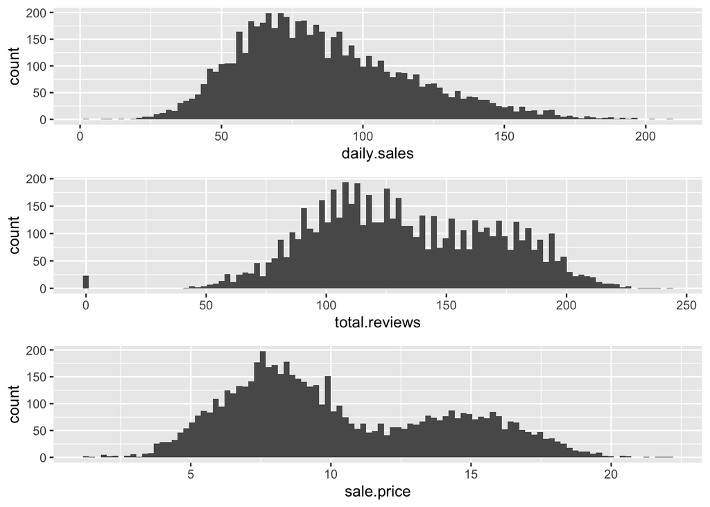

```r
# Check outliers
grid.arrange(
ggplot(sales) + geom_histogram(aes(daily.sales), bins = 100),
ggplot(sales) + geom_histogram(aes(total.reviews), bins = 100),
ggplot(sales) + geom_histogram(aes(sale.price), bins = 100)
)
```

No obvious or unreasonable outliers (0 total reviews of a book is reasonable in this case) for daily sales, total reviews and sale price are needed to be removed.

## Regressions on the number of sales

### The effect among average review scores and total number of reviews without interaction

```r
m.sales.by.avg.total = lm(daily.sales~avg.review + total.reviews, data=sales)
summary(m.sales.by.avg.total)
```

```
##
## Call:
## lm(formula = daily.sales ~ avg.review + total.reviews, data = sales)
##
## Residuals:
##      Min       1Q   Median       3Q      Max
## -101.601  -14.542   -0.921   13.659  129.764
##
## Coefficients:
##                Estimate Std. Error t value Pr(>|t|)
## (Intercept)   33.936412   2.354584  14.413   <2e-16 ***
## avg.review    -4.299240   0.514143  -8.362   <2e-16 ***
## total.reviews  0.533636   0.007738  68.961   <2e-16 ***
## ---
## Signif. codes:  0 '***' 0.001 '**' 0.01 '*' 0.05 '.' 0.1 ' ' 1
##
## Residual standard error: 22.56 on 5996 degrees of freedom
## Multiple R-squared:  0.4425, Adjusted R-squared:  0.4423
## F-statistic:  2380 on 2 and 5996 DF,  p-value: < 2.2e-16
```

```r
cbind(coef(m.sales.by.avg.total), confint(m.sales.by.avg.total))
```

```
##                              2.5 %     97.5 %
## (Intercept)   33.936412 29.3205808 38.5522436
## avg.review    -4.299240 -5.3071441 -3.2913350
## total.reviews  0.533636  0.5184662  0.5488058
```

The result shows that there is a significant negative effect of average review scores on daily sales (b = -4.30, CI[-5.31, -3.29], t(5996) = -8.36, p < 0.001), whereas there is a significant positive effect of total reviews on daily sales (b= 0.53, CI[0.52, 0.55], t(5996) = 68.96, p < 0.001).

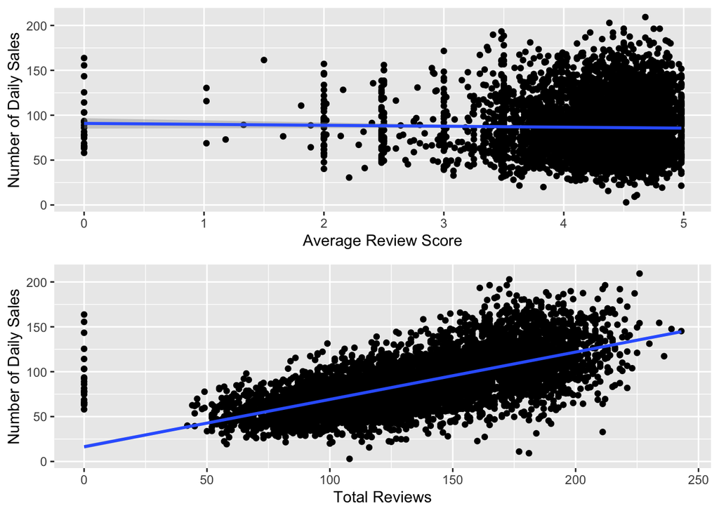

```r
# Plot graphs to see the effect of average review scores and total number of reviews on the number of sales
grid.arrange(
ggplot(sales, aes(y=daily.sales, x=avg.review)) + geom_point() + geom_smooth(method = lm) + labs(x="Average Review Score", y="Number of Daily Sales"),
ggplot(sales, aes(y=daily.sales, x=total.reviews)) + geom_point() + geom_smooth(method = lm) + labs(x="Total Reviews", y="Number of Daily Sales")
)
```

We can see that there is a very weak negative correlation between daily sales and average review scores and a positive correlation between daily sales and total reviews.

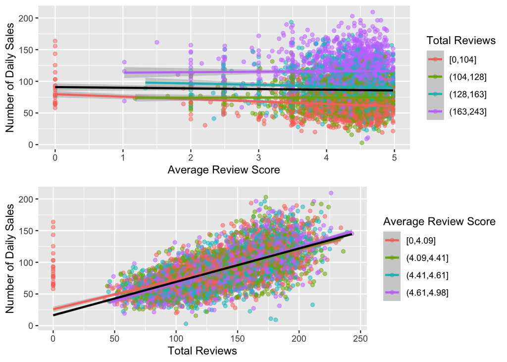

```r
# Separate the average view scores and total views into 4 different bins by quartiles to see if there are different effects on each other for different quartiles
avg.review.bins <- quantile(pull(sales, avg.review))
sales <- sales %>% mutate(avg.review.bin=cut(avg.review, avg.review.bins, include.lowest=TRUE))

total.reviews.bins <- quantile(pull(sales, total.reviews))
sales <- sales %>% mutate(total.reviews.bin=cut(total.reviews, total.reviews.bins, include.lowest=TRUE))

grid.arrange(
    ggplot(sales, aes(x=avg.review, y=daily.sales, col=total.reviews.bin)) + geom_point(alpha=0.5) + geom_smooth(method=lm) + geom_smooth(mapping=aes(col=NULL), method=lm, col="black") + labs(x="Average Review Score", y="Number of Daily Sales", col="Total Reviews"),
    ggplot(sales, aes(x=total.reviews, y=daily.sales, col=avg.review.bin)) + geom_point(alpha=0.5) + geom_smooth(method=lm) + geom_smooth(mapping=aes(col=NULL), method=lm, col="black") + labs(x="Total Reviews", y="Number of Daily Sales", col="Average Review Score")
)
```

We can see that lines are a little separated and the dot colors for the higher total reviews quartiles are higher up, indicating more daily sales for higher total reviews quartiles. On the other hand, there are almost no differences for different lines for average review scores in the relationship of total reviews and daily sales.

```r
# The vif scores are all low without interaction terms
vif(m.sales.by.avg.total)
```

```
##    avg.review total.reviews
##      1.008461      1.008461
```

### The effect among average review scores and total number of reviews with interaction

```r
m.sales.by.avg.total.intr = lm(daily.sales~avg.review * total.reviews, data=sales)
summary(m.sales.by.avg.total.intr)
```

```
##
## Call:
## lm(formula = daily.sales ~ avg.review * total.reviews, data = sales)
##
## Residuals:
##      Min       1Q   Median       3Q      Max
## -104.349  -14.402   -0.872   13.608   94.368
##
## Coefficients:
##                            Estimate Std. Error t value Pr(>|t|)
## (Intercept)               76.109877   4.162990  18.283  < 2e-16 ***
## avg.review               -14.677155   0.989837 -14.828  < 2e-16 ***
## total.reviews              0.139630   0.033149   4.212 2.57e-05 ***
## avg.review:total.reviews   0.095721   0.007836  12.215  < 2e-16 ***
## ---
## Signif. codes:  0 '***' 0.001 '**' 0.01 '*' 0.05 '.' 0.1 ' ' 1
##
## Residual standard error: 22.28 on 5995 degrees of freedom
## Multiple R-squared:  0.4561, Adjusted R-squared:  0.4558
## F-statistic:  1676 on 3 and 5995 DF,  p-value: < 2.2e-16
```

```r
cbind(coef(m.sales.by.avg.total.intr), confint(m.sales.by.avg.total.intr))
```

```
##                                             2.5 %      97.5 %
## (Intercept)               76.1098768  67.94891812  84.2708355
## avg.review               -14.6771555 -16.61759237 -12.7367186
## total.reviews              0.1396296   0.07464558   0.2046137
## avg.review:total.reviews   0.0957214   0.08035944   0.1110834
```

The result shows that there is a significant negative effect of average review scores on daily sales (b = -14.68, CI[-16.62, -12.74], t(5995) = -14.83, p < 0.001), and a significant positive effect of total reviews on daily sales (b = 0.14, CI[0.07, 0.20], t(5995) = 4.21, p < 0.001). There is also a significant positive interaction between average review scores and total reviews (b = 0.10, CI[0.08, 0.11], t(5995) = 12.22, p < 0.001).

```r
# There is a relatively high significant correlation of 0.66 between daily.sales and total.reviews
rcorr(as.matrix(select(sales, daily.sales, avg.review, total.reviews)))
```

```
##               daily.sales avg.review total.reviews
## daily.sales          1.00      -0.02          0.66
## avg.review          -0.02       1.00          0.09
## total.reviews        0.66       0.09          1.00
##
## n= 5999
##
##
## P
##               daily.sales avg.review total.reviews
## daily.sales               0.1251     0.0000
## avg.review    0.1251                 0.0000
## total.reviews 0.0000      0.0000
```

```r
# The high vif scores on total reviews and the interaction term suggest that there is a multicollinearity problem, so we shouldn't consider the interaction effect
vif(m.sales.by.avg.total.intr)
```

```
## there are higher-order terms (interactions) in this model
## consider setting type = 'predictor'; see ?vif
```

```
##               avg.review            total.reviews avg.review:total.reviews
##                 3.830219                18.963481                23.080722
```

```r
anova(m.sales.by.avg.total,m.sales.by.avg.total.intr)
```

```
## Analysis of Variance Table
##
## Model 1: daily.sales ~ avg.review + total.reviews
## Model 2: daily.sales ~ avg.review * total.reviews
##   Res.Df     RSS Df Sum of Sq      F    Pr(>F)
## 1   5996 3050562
## 2   5995 2976480  1     74082 149.21 < 2.2e-16 ***
## ---
## Signif. codes:  0 '***' 0.001 '**' 0.01 '*' 0.05 '.' 0.1 ' ' 1
```

Although the anova analysis shows that the model with interaction have a significant improvement (F(5996, 5995) = 149.21, p < 0.001), we wouldn’t adopt this model due to its high vif scores.

### The effect of sale price

```r
m.sales.by.price = lm(daily.sales~sale.price, data=sales)
summary(m.sales.by.price)
```

```
##
## Call:
## lm(formula = daily.sales ~ sale.price, data = sales)
##
## Residuals:
##     Min      1Q  Median      3Q     Max
## -87.833 -17.389  -1.926  15.218 113.650
##
## Coefficients:
##              Estimate Std. Error t value Pr(>|t|)
## (Intercept) 127.36554    0.95625  133.19   <2e-16 ***
## sale.price   -3.97938    0.08695  -45.77   <2e-16 ***
## ---
## Signif. codes:  0 '***' 0.001 '**' 0.01 '*' 0.05 '.' 0.1 ' ' 1
##
## Residual standard error: 26.01 on 5997 degrees of freedom
## Multiple R-squared:  0.2589, Adjusted R-squared:  0.2587
## F-statistic:  2095 on 1 and 5997 DF,  p-value: < 2.2e-16
```

```r
cbind(coef(m.sales.by.price), confint(m.sales.by.price))
```

```
##                             2.5 %     97.5 %
## (Intercept) 127.365538 125.490940 129.240136
## sale.price   -3.979376  -4.149824  -3.808927
```

The result shows that there is a significant negative effect of sale price on the number of sales (b = -3.98, CI[-4.15, -3.81], t(5997) = -45.77, p < 0.001).

### The effect of sale price and different genres without interaction

```r
m.sales.by.price.genres = lm(daily.sales~sale.price + genre, data=sales)
summary(m.sales.by.price.genres)
```

```
##
## Call:
## lm(formula = daily.sales ~ sale.price + genre, data = sales)
##
## Residuals:
##      Min       1Q   Median       3Q      Max
## -103.208  -13.718    0.276   13.550   96.238
##
## Coefficients:
##                  Estimate Std. Error t value Pr(>|t|)
## (Intercept)       93.9760     1.2410  75.724  < 2e-16 ***
## sale.price        -1.4334     0.1429 -10.034  < 2e-16 ***
## genrenon_fiction  -9.0085     1.2197  -7.386 1.72e-13 ***
## genreYA_fiction   30.5358     0.6977  43.764  < 2e-16 ***
## ---
## Signif. codes:  0 '***' 0.001 '**' 0.01 '*' 0.05 '.' 0.1 ' ' 1
##
## Residual standard error: 22.06 on 5995 degrees of freedom
## Multiple R-squared:  0.4668, Adjusted R-squared:  0.4665
## F-statistic:  1749 on 3 and 5995 DF,  p-value: < 2.2e-16
```

```r
cbind(coef(m.sales.by.price.genres), confint(m.sales.by.price.genres))
```

```
##                                 2.5 %    97.5 %
## (Intercept)      93.976005  91.543131 96.408880
## sale.price       -1.433434  -1.713495 -1.153373
## genrenon_fiction -9.008536 -11.399539 -6.617532
## genreYA_fiction  30.535784  29.167973 31.903595
```

The result shows that there is a significant negative effect of sale price (b = -1.43, CI[-1.71, -1.15], t(5995) = -10.03, p < 0.001) on the number of sales when holding the genre constant. Furthermore, compared to adult fiction, there is a negative effect of non fiction (b = -9.01, CI[-11.40, -6.62], t(5995) = -7.39, p < 0.001), while there is a positive effect of YA fiction (b = 30.54, CI = [29.17, 31.90], t(5995) = 43.76, p < 0.001).

```r
# The vif scores are all low without interaction terms
vif(m.sales.by.price.genres)
```

```
##                GVIF Df GVIF^(1/(2*Df))
## sale.price 3.751295  1        1.936826
## genre      3.751295  2        1.391699
```

The intercept of regression is adult fiction, so we cannot see the effect of each genre separately. Hence, we plot it on the graph.

```r
(m.sales.by.price.genres.emm = emmeans(m.sales.by.price.genres, ~genre))
```

```
##  genre         emmean    SE   df lower.CL upper.CL
##  adult_fiction   79.2 0.595 5995     78.0     80.4
##  non_fiction     70.2 0.830 5995     68.6     71.8
##  YA_fiction     109.8 0.597 5995    108.6    110.9
##
## Confidence level used: 0.95
```

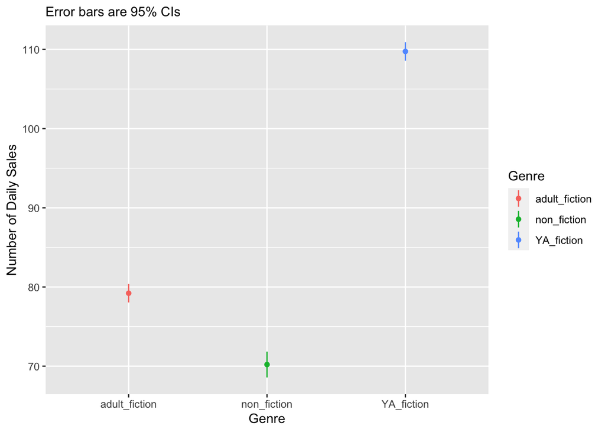

```r
# Plot the graph to solely observe the effect of genres on the number of sales
ggplot(summary(m.sales.by.price.genres.emm), aes(x=genre, y=emmean, ymin=lower.CL, ymax=upper.CL, color=genre)) + geom_point() + geom_linerange() + labs(x="Genre", y="Number of Daily Sales", col="Genre", subtitle="Error bars are 95% CIs")
```

If we only observe the effect of genres on the daily sales, we can only get a simple conclusion that YA fiction has the highest book sales, followed by adult fiction and non fiction.

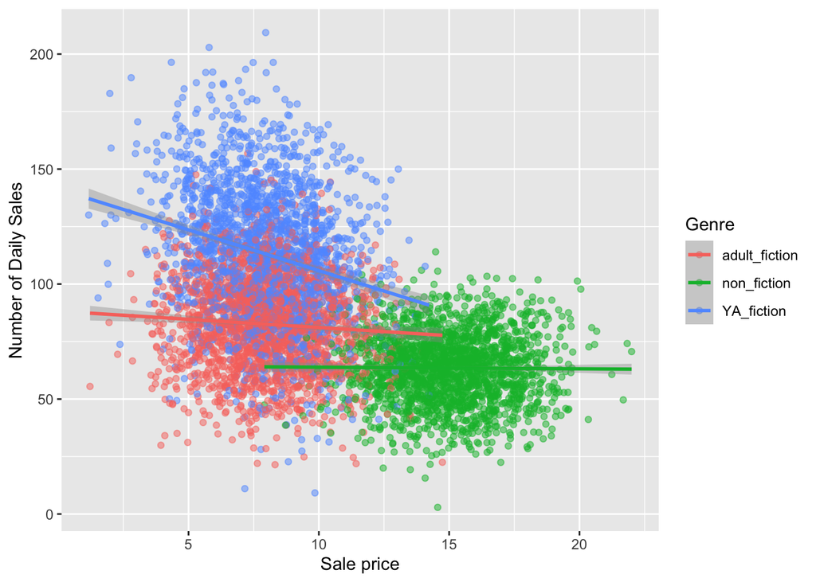

```r
# This graph can clearly show the effect of sale price on daily sales by different genres
ggplot(sales, aes(y=daily.sales, x=sale.price, color=genre)) + geom_point(alpha = 0.5) + geom_smooth(method = lm) + labs(x="Sale price", y="Number of Daily Sales", col="Genre")
```

When we also include the effect of sale price, we can get more results that non fiction has the highest sale price with the lowest daily sales, while YA fiction has a lower sale price and higher daily sales. However, even if adult fiction has the similar sale price pattern with YA fiction, it has lower daily sales than that.

### The effect of sale price and different genres with interaction

```r
m.sales.by.price.genres.intr = lm(daily.sales~sale.price * genre, data=sales)
summary(m.sales.by.price.genres.intr)
```

```
##
## Call:
## lm(formula = daily.sales ~ sale.price * genre, data = sales)
##
## Residuals:
##      Min       1Q   Median       3Q      Max
## -104.871  -13.693    0.189   13.512   96.266
##
## Coefficients:
##                             Estimate Std. Error t value Pr(>|t|)
## (Intercept)                  88.2127     2.0410  43.220  < 2e-16 ***
## sale.price                   -0.7104     0.2486  -2.858  0.00428 **
## genrenon_fiction            -23.6300     4.1811  -5.652 1.66e-08 ***
## genreYA_fiction              53.0879     2.8657  18.525  < 2e-16 ***
## sale.price:genrenon_fiction   0.6383     0.3466   1.842  0.06556 .
## sale.price:genreYA_fiction   -2.8356     0.3494  -8.115 5.83e-16 ***
## ---
## Signif. codes:  0 '***' 0.001 '**' 0.01 '*' 0.05 '.' 0.1 ' ' 1
##
## Residual standard error: 21.86 on 5993 degrees of freedom
## Multiple R-squared:  0.4768, Adjusted R-squared:  0.4763
## F-statistic:  1092 on 5 and 5993 DF,  p-value: < 2.2e-16
```

```r
cbind(coef(m.sales.by.price.genres.intr), confint(m.sales.by.price.genres.intr))
```

```
##                                                2.5 %      97.5 %
## (Intercept)                  88.2127260  84.21158297  92.2138691
## sale.price                   -0.7104194  -1.19776655  -0.2230723
## genrenon_fiction            -23.6300182 -31.82644277 -15.4335936
## genreYA_fiction              53.0878974  47.47006480  58.7057301
## sale.price:genrenon_fiction   0.6383178  -0.04111713   1.3177528
## sale.price:genreYA_fiction   -2.8356112  -3.52059146  -2.1506310
```

The result shows that there is a significant negative effect of sale price (b = -0.71, CI[-1.20, -0.22], t(5993) = -2.86, p = 0.0043), non fiction (b = -23.63, CI[-31.83, -15.43], t(5993) = -5.65, p < 0.001) and interaction between sale price and YA fiction (b = -2.84, CI[-3.52, -2.15], t(5993) = -8.12, p < 0.001) on daily sales whereas a significant positive effect of YA fiction (b = 53.09, CI[47.47, 58.71], t(5993) = 18.53, p < 0.001). However, there is no significant interaction between sale price and non fiction (b = 0.6383, CI[-0.04, 1.32], t(5993) = 1.84, p = 0.066).

```r
# The vif scores of genre and the interaction between sale price and genre are higher than 5, meaning that there is a multicollinearity problem, so we shouldn't consider the interaction effect
vif(m.sales.by.price.genres.intr)
```

```
## there are higher-order terms (interactions) in this model
## consider setting type = 'predictor'; see ?vif
```

```
##                        GVIF Df GVIF^(1/(2*Df))
## sale.price         11.57205  1        3.401772
## genre             737.01865  2        5.210383
## sale.price:genre 1045.36142  2        5.686128
```

```r
anova(m.sales.by.price.genres, m.sales.by.price.genres.intr)
```

```
## Analysis of Variance Table
##
## Model 1: daily.sales ~ sale.price + genre
## Model 2: daily.sales ~ sale.price * genre
##   Res.Df     RSS Df Sum of Sq      F    Pr(>F)
## 1   5995 2917765
## 2   5993 2863176  2     54590 57.132 < 2.2e-16 ***
## ---
## Signif. codes:  0 '***' 0.001 '**' 0.01 '*' 0.05 '.' 0.1 ' ' 1
```

Although the anova analysis shows that the model with interaction have a significant improvement (F(5995, 5993) = 57.13, p < 0.001), we wouldn’t adopt this model due to its high vif scores.

# Conclusion

This section presents the results of the analyses that examine the effect on the number of book sales. The analysis was conducted using the data provided for 6000 different kinds of e-book sales. The dataset contains no missing value while a record with a negative number of sales is removed, and hence 5999 records are left.

The regression result shows that a unit of average review scores can significantly decrease 4.30 units (CI[-5.31, -3.29], t(5996) = -8.36, p < 0.001) on the number of sales, while a unit of total reviews can significantly increase 0.53 units (CI[0.52, 0.55], t(5996) = 68.96, p < 0.001) on that. Overall, books have fewer sales depending on their average review scores whereas more sales depending on the total number of reviews.

When we only consider the effect of sale price on the number of sales, the regression result shows that an average of £1 increase on sale price significantly decrease 3.98 units (CI[-4.15, -3.81], t(5997) = -45.77, p < 0.001) on the number of sales. Simply put, sale price has a negative effect on the number of sales.

When we also include the effect of genres, an average of £1 increase on sale price significantly decrease 1.43 (CI[-1.71, -1.15], t(5995) = -10.03, p < 0.001) units on the number of sales when holding the genre constant. In addition, compared to adult fiction, the number of sales in non fiction is significantly lower by 9.01 units (CI[-11.40, -6.62], t(5995) = -7.39, p < 0.001), whereas YA fiction is significantly higher by 30.54 units (CI = [29.17, 31.90], t(5995) = 43.76, p < 0.001). In simple terms, after considering the effect of genres, sale price still has a negative effect on the number of sales. For genres, when setting the base line of adult fiction, the effect of non fiction is lower while that of YA fiction is much higher.